# Exam II

Jacob Harrell

3/22/2021

**Question 1**

Import dataset into r and examine the first few rows of data

```r
#setwd(choose.dir('Exam2.csv'))
exam <- read.csv(file = 'Exam2.csv')

head(exam)
```

```
##    y          x1          x2 x3
## 1  2  1.37034210 -0.66615843  b
## 2  2 -0.70417232 -0.03705622  c
## 3  4 -0.04223752 -1.53148692  c
## 4  9 -0.56711072 -0.06529335  b
## 5  1  0.31189773  0.81650472  a
## 6 13 -0.35994479 -0.80042308  b
```

**Question 2**

Fit a Poisson Model assuming response is a function of x1, x2, and x3. Include an interaction between x1 and x2 only.

```r
fit<-glm(y~x1*x2+x3, family = poisson, data = exam)
summary(fit)
```

```
##
## Call:
## glm(formula = y ~ x1 * x2 + x3, family = poisson, data = exam)
##
## Deviance Residuals:
##     Min       1Q   Median       3Q      Max
## -2.3620  -0.6973  -0.1007   0.5236   2.6779
##
## Coefficients:
##             Estimate Std. Error z value Pr(>|z|)
## (Intercept)  1.13258    0.08540  13.262  < 2e-16 ***
## x1          -1.03491    0.05019 -20.620  < 2e-16 ***
## x2          -0.90839    0.06977 -13.021  < 2e-16 ***
## x3b          0.37532    0.09246   4.059 4.92e-05 ***
## x3c         -0.88354    0.12072  -7.319 2.50e-13 ***
## x1:x2       -0.28868    0.05142  -5.614 1.98e-08 ***
## ---
## Signif. codes:  0 '***' 0.001 '**' 0.01 '*' 0.05 '.' 0.1 ' ' 1
##
## (Dispersion parameter for poisson family taken to be 1)
##
##     Null deviance: 720.551  on 99  degrees of freedom
## Residual deviance:  89.088  on 94  degrees of freedom
## AIC: 392.86
##
## Number of Fisher Scoring iterations: 5
```

**Question 3**

Interpret the effect of variable x1 when x2 = -1.

```r
beta<-coef(fit)
beta[2]+beta[6]*1
```

```
##        x1
## -1.323587
```

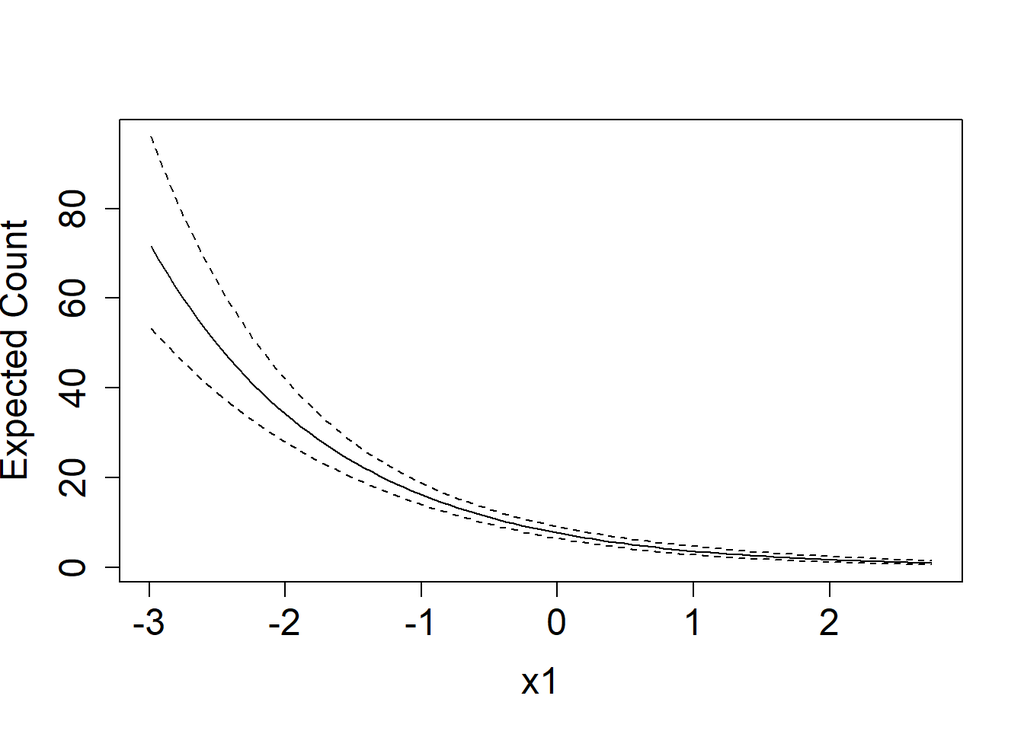

```r
newdat<-data.frame( x1 = seq(min(exam$x1), max(exam$x1), length.out = 100), x2 = -1, x3 = factor(x = rep('a', times = 100), levels = c('a', 'b', 'c')))

prd<-predict.glm(object = fit, newdata = newdat, type = 'link', se.fit = T)
low<-prd$fit-qnorm(.975)*prd$se.fit
high<-prd$fit+qnorm(.975)*prd$se.fit

plot(y=exp(prd$fit), x=newdat$x1, ylab = 'Expected Count', xlab = 'x1', cex.axis = 1.5, cex.lab = 1.5, type = 'l', ylim = c(min(exp(low)), max(exp(high))))
lines(x = newdat$x1, y = exp(low), lty = 2)
lines(x = newdat$x1, y = exp(high), lty = 2)
```

**Question 5** Interpret the effect of variable x3.

```r
(exp(beta[4])-1)*100
```

```
##      x3b
## 45.54593
```

```r
(exp(beta[5])-1)*100
```

```
##       x3c
## -58.66834
```

The slope coefficient for X3 is positively related to the categorical variable of x3 when moving from level ‘a’ to level ‘b’, but negatively related when moving from level ‘a’ to level ‘c’. The expected count increases by approximately 45.55% when moving from level ‘a’ to level ‘b’ and the expected count decreases by approximately 58.67% when moving from level ‘a’ to level ‘c’.

**Question 6** Use contrasts to evaluate null hypothesis that difference in log expected counts between ‘b’ and ‘c’ is 0. fix x1 and x2 to their means.

```r
#install.packages('multcomp')
library(multcomp)
m<-matrix(c(0,0,0,1,-1,0),nrow=1)
cntr<- glht(model = fit, m)
cntr
```

```
##
##   General Linear Hypotheses
##
## Linear Hypotheses:
##        Estimate
## 1 == 0    1.259
```

```r
summary(cntr)
```

```
##
##   Simultaneous Tests for General Linear Hypotheses
##
## Fit: glm(formula = y ~ x1 * x2 + x3, family = poisson, data = exam)
##
## Linear Hypotheses:
##        Estimate Std. Error z value Pr(>|z|)
## 1 == 0   1.2589     0.1197   10.52   <2e-16 ***
## ---
## Signif. codes:  0 '***' 0.001 '**' 0.01 '*' 0.05 '.' 0.1 ' ' 1
## (Adjusted p values reported -- single-step method)
```

we would reject the null hypothesis that the difference in log expected counts between ‘b’ and ‘c’ = 0 since the associated p-value is so small.

**Question 7** Derive the test statistic and p-value associated with the interaction between x1 and x2.

```r
s<-summary(fit)[['coefficients']][,2]
ts<-beta[6]/s
ts
```

```
## (Intercept)          x1          x2         x3b         x3c       x1:x2
##   -3.380447   -5.751847   -4.137864   -3.122191   -2.391257   -5.614074
```

```r
pst<-pnorm(-1*abs(ts))*2
pst
```

```
##  (Intercept)           x1           x2          x3b          x3c        x1:x2
## 7.236798e-04 8.827355e-09 3.505541e-05 1.795104e-03 1.679081e-02 1.976182e-08
```

The null hypothesis is that the change between x1 and x2 is equal to 0. In other words beta[6]=0. We would reject the null hypothesis since the associated p-value is insignificantly small.

**Question 8**

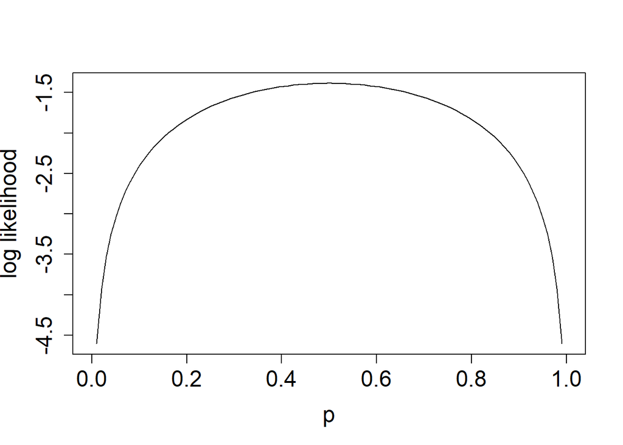

```r
y<-c(0,1)
lik<-function(p,y){
  sum(dbinom(y, size =1, prob = p, log = -2))
}

p<-seq(from=0, to=1, length.out = 100)
ll<-numeric(100)
for(i in 1:100){
  ll[i]<-lik(p[i], y)
}

plot(x=p, y=ll, ylab='log likelihood', xlab = 'p', cex.axis = 1.5, cex.lab = 1.5, type = 'l')
```